# 452_Assignment_6

Shaolong (Fred) Xue

2023-02-25

```r
library(tree)
library(randomForest)
```

```r
library(rpart)
library(rpart.plot)
```

### Question 1 - PCA

#### Part 1 - How does PCA reduce variables?

PCA projects data from higher dimensional space is mapped to data in a lower dimensional space (e.g. 2D), while maximizing the variance or spread of data in the lower dimensional space. The full process of PCA involves a couple of steps: calculating the covariance matrix and sort the eigenvectors by eigenvalues, choose a cut-off component usually by looking at a plot (e.g. elbow), and transform the data to lower dimensions.

Note, dimension reduction (DR) only happens if we apply the last step of transforming the data. That’s when we essentially rotate the coordinate system in a way that captures maximum variance in lower dimensions. And we decide to explain the data with this reduced dimensional space (e.g. 100D to 2D). Otherwise, PCA itself is “lossless” before transformation.

#### Part 2 - Limitations of PCA

A downside of PCA is that the statistic outcome of the PCA is difficult to interpret and conceptualize. It’s hard to put into words what the values for each variable within a principle component mean.

Standardization is also a crucial pre-requisite, so scaling of the data is required for PCA.

Also, choosing the number of principle components to keep is arbitrary and subjective. 75% total variance explained is a typical cut-off, but there’s no clear rule so the results can vary from case to case and people to people.

PCA works best if the data is linear. If the relationship between variables are non-linear, DR outcome may not be appropriate.

### Question 2 - Trees

The essence of decision trees is maximizing data likelihood or minimizing deviance, as usual. But instead of linear coefficients, decision trees have decision nodes. These are split-rules defined by some thresholds on some dimension of x variables.

A tree is grown through a sequence of splits. We start with all x variables at the top. At each decision node, the observations are split either left or right, depending on the split-rule (functions). Each split is independent from another. At the bottom, we have leaf nodes that contain the data subsets allocated based on the splits. Each subset is the average of sample y values. Usually, there are stopping rules like minimum number of observations within each leaf to stop a tree from growing further.

Overall, decision trees minimize heterogeneity (deviance) among all leaf nodes and maximize homogeneity within each leaf node.

There are two types trees: classification and regression trees (CART). The general way they are grown is the same. The difference is that classification trees have class probabilities at the leaf nodes (e.g. probability of raining), while regression trees have mean y values at the lead nodes (e.g. expected amount of rain).

### Question 3 - How is a Tree Pruned?

The motivation for pruning a tree is that CART can result in overfitting because the decision tree algorithm is greedy (has no defined stopping point). In other words, the tree may grow unwanted leaf nodes.

Pruning a tree is usually done from the bottom up. We remove the split that contributes least to deviance reduction. This is a backward check on improvement to out-of-sample (OOS) performance. With each split pruned, we get a new candidate tree. The result of pruning is a group of candidate trees. We then use cross validation (CV) to choose the candidate tree with the best OOS performance. A visible outcome is that pruned trees have less leaf nodes.

### Question 4 - Random Forest vs Regression

Overall, parametric techniques such as regular linear regressions require certain assumptions such as linearity. When these assumptions are not met, which is usually the case in the real world, predictions from regressions can be unreliable. Un-parametric techniques, such as random forest, do not rely on such assumptions. Therefore, they usually outperform regression models in this sense.

To dive in more specifically, random forest applies a model averaging technique of non-parametric algorithms. It averages over a bootstrapped sample of trees to reveal real patterns in the data. And very nicely, noisy signals usually get averaged out in the process. In other words, trees “protect” each other from their individual errors. As each tree is an independent estimate and is not overly complicated because it contains a limited subset of variables, averaging them out produces the optimal estimate, better accuracy and less bias.

In addition to protection against noise and outliers, bootstrapping and the subset of variables within each tree component of a random forest helps limit overfitting. And even though random forest doesn’t produce a nice single tree for you to easily interpret the result, it provides OOS variable importance where you can easily identify important features.

Lastly, you don’t have to worry about specifying interaction detection because decision trees does that automatically. ### Question 5 - Transactions Dataset

```r
transaction <- read.csv("Transaction.csv")
head(transaction)
```

```
##   ID LIMIT_BAL SEX EDUCATION MARRIAGE AGE PAY_0 PAY_2 PAY_3 PAY_4 PAY_5 PAY_6
## 1  1     20000   2         2        1  24     2     2    -1    -1    -2    -2
## 2  2    120000   2         2        2  26    -1     2     0     0     0     2
## 3  3     90000   2         2        2  34     0     0     0     0     0     0
## 4  4     50000   2         2        1  37     0     0     0     0     0     0
## 5  5     50000   1         2        1  57    -1     0    -1     0     0     0
## 6  6     50000   1         1        2  37     0     0     0     0     0     0
##   BILL_AMT1 BILL_AMT2 BILL_AMT3 BILL_AMT4 BILL_AMT5 BILL_AMT6 PAY_AMT1 PAY_AMT2
## 1      3913      3102       689         0         0         0        0      689
## 2      2682      1725      2682      3272      3455      3261        0     1000
## 3     29239     14027     13559     14331     14948     15549     1518     1500
## 4     46990     48233     49291     28314     28959     29547     2000     2019
## 5      8617      5670     35835     20940     19146     19131     2000    36681
## 6     64400     57069     57608     19394     19619     20024     2500     1815
##   PAY_AMT3 PAY_AMT4 PAY_AMT5 PAY_AMT6 payment_default
## 1        0        0        0        0               1
## 2     1000     1000        0     2000               1
## 3     1000     1000     1000     5000               0
## 4     1200     1100     1069     1000               0
## 5    10000     9000      689      679               0
## 6      657     1000     1000      800               0
```

```r
summary(transaction)
```

```
##        ID          LIMIT_BAL            SEX          EDUCATION
##  Min.   :    1   Min.   :  10000   Min.   :1.000   Min.   :0.000
##  1st Qu.: 7501   1st Qu.:  50000   1st Qu.:1.000   1st Qu.:1.000
##  Median :15000   Median : 140000   Median :2.000   Median :2.000
##  Mean   :15000   Mean   : 167484   Mean   :1.604   Mean   :1.853
##  3rd Qu.:22500   3rd Qu.: 240000   3rd Qu.:2.000   3rd Qu.:2.000
##  Max.   :30000   Max.   :1000000   Max.   :2.000   Max.   :6.000
##     MARRIAGE          AGE            PAY_0             PAY_2
##  Min.   :0.000   Min.   :21.00   Min.   :-2.0000   Min.   :-2.0000
##  1st Qu.:1.000   1st Qu.:28.00   1st Qu.:-1.0000   1st Qu.:-1.0000
##  Median :2.000   Median :34.00   Median : 0.0000   Median : 0.0000
##  Mean   :1.552   Mean   :35.49   Mean   :-0.0167   Mean   :-0.1338
##  3rd Qu.:2.000   3rd Qu.:41.00   3rd Qu.: 0.0000   3rd Qu.: 0.0000
##  Max.   :3.000   Max.   :79.00   Max.   : 8.0000   Max.   : 8.0000
##      PAY_3             PAY_4             PAY_5             PAY_6
##  Min.   :-2.0000   Min.   :-2.0000   Min.   :-2.0000   Min.   :-2.0000
##  1st Qu.:-1.0000   1st Qu.:-1.0000   1st Qu.:-1.0000   1st Qu.:-1.0000
##  Median : 0.0000   Median : 0.0000   Median : 0.0000   Median : 0.0000
##  Mean   :-0.1662   Mean   :-0.2207   Mean   :-0.2662   Mean   :-0.2911
##  3rd Qu.: 0.0000   3rd Qu.: 0.0000   3rd Qu.: 0.0000   3rd Qu.: 0.0000
##  Max.   : 8.0000   Max.   : 8.0000   Max.   : 8.0000   Max.   : 8.0000
##    BILL_AMT1         BILL_AMT2        BILL_AMT3         BILL_AMT4
##  Min.   :-165580   Min.   :-69777   Min.   :-157264   Min.   :-170000
##  1st Qu.:   3559   1st Qu.:  2985   1st Qu.:   2666   1st Qu.:   2327
##  Median :  22382   Median : 21200   Median :  20088   Median :  19052
##  Mean   :  51223   Mean   : 49179   Mean   :  47013   Mean   :  43263
##  3rd Qu.:  67091   3rd Qu.: 64006   3rd Qu.:  60165   3rd Qu.:  54506
##  Max.   : 964511   Max.   :983931   Max.   :1664089   Max.   : 891586
##    BILL_AMT5        BILL_AMT6          PAY_AMT1         PAY_AMT2
##  Min.   :-81334   Min.   :-339603   Min.   :     0   Min.   :      0
##  1st Qu.:  1763   1st Qu.:   1256   1st Qu.:  1000   1st Qu.:    833
##  Median : 18104   Median :  17071   Median :  2100   Median :   2009
##  Mean   : 40311   Mean   :  38872   Mean   :  5664   Mean   :   5921
##  3rd Qu.: 50190   3rd Qu.:  49198   3rd Qu.:  5006   3rd Qu.:   5000
##  Max.   :927171   Max.   : 961664   Max.   :873552   Max.   :1684259
##     PAY_AMT3         PAY_AMT4         PAY_AMT5           PAY_AMT6
##  Min.   :     0   Min.   :     0   Min.   :     0.0   Min.   :     0.0
##  1st Qu.:   390   1st Qu.:   296   1st Qu.:   252.5   1st Qu.:   117.8
##  Median :  1800   Median :  1500   Median :  1500.0   Median :  1500.0
##  Mean   :  5226   Mean   :  4826   Mean   :  4799.4   Mean   :  5215.5
##  3rd Qu.:  4505   3rd Qu.:  4013   3rd Qu.:  4031.5   3rd Qu.:  4000.0
##  Max.   :896040   Max.   :621000   Max.   :426529.0   Max.   :528666.0
##  payment_default
##  Min.   :0.0000
##  1st Qu.:0.0000
##  Median :0.0000
##  Mean   :0.2212
##  3rd Qu.:0.0000
##  Max.   :1.0000
```

```r
# converting dbl to factor for binary variables such as sex and payment_default
transaction$PAYMENT_DEFAULT <- as.factor(transaction$payment_default)
transaction$SEX <- as.factor(transaction$SEX)

index <- sample(1:nrow(transaction), size = 0.8*nrow(transaction), replace = FALSE)
tran_train <- transaction[index,]
tran_test <- transaction[-index,]
```

#### CART

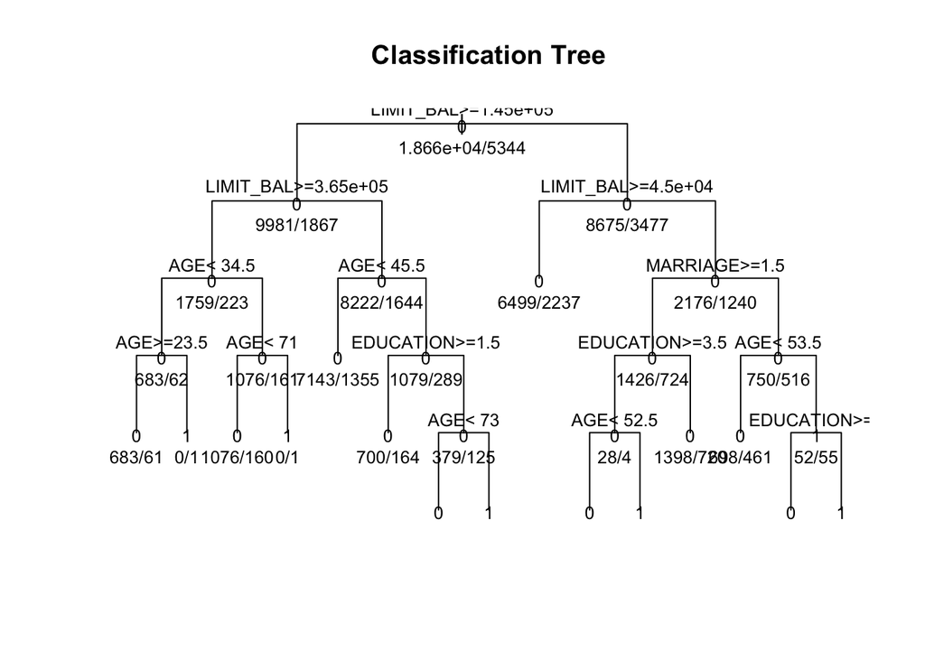

```r
## setting values to control tree growth
ctrl <- rpart.control(minsplit = 1, minbucket = 1, cp = 0, maxdepth = 5)

tree <- rpart(PAYMENT_DEFAULT ~ LIMIT_BAL + SEX + EDUCATION + AGE + MARRIAGE, data = tran_train, method = "class", control = ctrl)

## plot the tree
plot(tree, uniform = TRUE, main = "Classification Tree")
text(tree, use.n = TRUE, all = TRUE, cex = 0.8)
```

```r
## predict with CART
tree_pred <- predict(tree, newdata = tran_test, type= "class")
acc_tree <- mean(tree_pred == tran_test$PAYMENT_DEFAULT)
```

The prediction accuracy of the CART model is about **0.7782**.

#### Random Forest

```r
rf <- randomForest(PAYMENT_DEFAULT ~ LIMIT_BAL + SEX + EDUCATION + AGE + MARRIAGE, data = tran_train, ntree = 500)

print(rf)
```

```
##
## Call:
##  randomForest(formula = PAYMENT_DEFAULT ~ LIMIT_BAL + SEX + EDUCATION +      AGE + MARRIAGE, data = tran_train, ntree = 500)
##                Type of random forest: classification
##                      Number of trees: 500
## No. of variables tried at each split: 2
##
##         OOB estimate of  error rate: 22.32%
## Confusion matrix:
##       0  1 class.error
## 0 18597 59 0.003162521
## 1  5299 45 0.991579341
```

```r
importance(rf)
```

```
##           MeanDecreaseGini
## LIMIT_BAL        668.86834
## SEX               59.17454
## EDUCATION        166.53807
## AGE              624.90135
## MARRIAGE          94.57571
```

```r
rf_pred <- predict(rf, newdata = tran_test)
acc_rf <- mean(rf_pred == tran_test$PAYMENT_DEFAULT)
```

The prediction accuracy of the random forest model is about **0.7783**.